# Global Clustering Based On Time Series Features

Clustering is a common unsupervised learning approach. The problem with time series is that the notion of “distance” between time series isn’t as straight forward as it is for independent multidimensional data points. Common distance metrics like euclidean or Manhattan distance don’t necessarily tell you about how close two different time series are and in many cases the results of those computations would go against the human intuition. A way to still use clustering algorithms (and classification algorithms for that matter) on time series data sets is to compute time series features - metrics like the first local extreme points, points below the mean, etc - and use all of those features in place of the original (univariate) time series.

In this document we try to apply this method on the stock data we collected in the data acquisition document. We will try to find meaningful clusters of tickers, look at their composition (which kind of companies can be found in these clusters) and at differences in their performance.

## Data Preparation

The chosen tickers currently aren’t on the same scale. We can remedy this by normalizing all values for each symbol. We’ll focus on the adjusted price which is the closing price after corrections for splits and dividend distributions.

| ticker | ref.date | standardized_price |
| --- | --- | --- |
| AAPL | 1999-01-04 | -0.6741328 |
| AAPL | 1999-01-05 | -0.6735652 |
| AAPL | 1999-01-06 | -0.6739952 |
| AAPL | 1999-01-07 | -0.6731009 |
| AAPL | 1999-01-08 | -0.6731009 |
| AAPL | 1999-01-09 | -0.6731009 |
| AAPL | 1999-01-10 | -0.6731009 |
| AAPL | 1999-01-11 | -0.6728602 |
| AAPL | 1999-01-12 | -0.6727913 |
| AAPL | 1999-01-13 | -0.6726881 |

[output cut: 990 more lines]

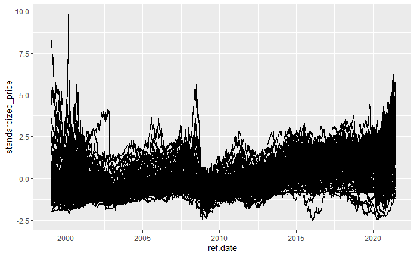

## Time Series Feature Computation

Working with raw time series values is both computationally expensive as well as generally hard to do right. To circumvent these problems researchers of all fields that use time series data have been doing extensive work to find features which represent time series as a vector of comparable features. One of those efforts culminated into the [Highly comparative time-series analysis package](https://github.com/benfulcher/hctsa) which allows to compute over 7000 features. Based on this work the researchers behind the [catch22 package](https://github.com/chlubba/catch22) selected 22 features which - on average - offer the best cost/benefit trade-off in regarding general time series clustering and classification tasks. As we do not have in-depth knowledge of econometrics we decided to go with the `catch22` set of features rather than hand-picking the best set of features ourselves.

| ticker | DN_HistogramMode_5 | DN_HistogramMode_10 | CO_f1ecac | CO_FirstMin_ac | CO_HistogramAMI_even_2_5 | CO_trev_1_num | MD_hrv_classic_pnn40 | SB_BinaryStats_mean_longstretch1 | SB_TransitionMatrix_3ac_sumdiagcov | PD_PeriodicityWang_th0_01 | CO_Embed2_Dist_tau_d_expfit_meandiff | IN_AutoMutualInfoStats_40_gaussian_fmmi | FC_LocalSimple_mean1_tauresrat | DN_OutlierInclude_p_001_mdrmd | DN_OutlierInclude_n_001_mdrmd | SP_Summaries_welch_rect_area_5_1 | SB_BinaryStats_diff_longstretch0 | SB_MotifThree_quantile_hh | SC_FluctAnal_2_rsrangefit_50_1_logi_prop_r1 | SC_FluctAnal_2_dfa_50_1_2_logi_prop_r1 | SP_Summaries_welch_rect_centroid | FC_LocalSimple_mean3_stderr |
| --- | --- | --- | --- | --- | --- | --- | --- | --- | --- | --- | --- | --- | --- | --- | --- | --- | --- | --- | --- | --- | --- | --- |
| AAPL | -1.675311e-01 | -0.422897121 | 988 | 4590 | 0.7228948 | -2.444203e-07 | 0.03670732 | 2589 | 0.166666667 | 918 | 2.6352930 | 40 | 0.0003505082 | 0.94494574 | -0.468967199 | 0.9986643 | 6 | 1.125257 | 0.20 | 0.22 | 0.0011504856 | 0.02477352 |
| ABT | -4.420886e-01 | -0.676584306 | 1063 | 5471 | 1.0035210 | -5.134954e-06 | 0.04207317 | 2690 | 0.166666667 | 0 | 2.3333854 | 40 | 0.0003644315 | 0.90525546 | -0.444092184 | 0.9990400 | 6 | 1.136799 | 0.12 | 0.16 | 0.0007669904 | 0.02504898 |
| ADM | -4.647916e-02 | -1.267905535 | 1516 | 451 | 1.1742625 | -1.300163e-05 | 0.11865854 | 3044 | 0.166666667 | 2696 | 3.4274611 | 40 | 0.0003469813 | 0.87361297 | -0.711010852 | 0.9988700 | 6 | 1.155075 | 0.26 | 0.86 | 0.0007669904 | 0.03655714 |
| ADP | -5.039532e-01 | -0.710124360 | 1319 | 5433 | 1.0673337 | -1.435339e-05 | 0.04134146 | 2620 | 0.074074074 | 0 | 2.0876322 | 40 | 0.0003894081 | 0.86513840 | -0.431654676 | 0.9990664 | 6 | 1.163721 | 0.14 | 0.14 | 0.0007669904 | 0.02498453 |
| ADSK | -3.442727e-01 | -0.593878124 | 969 | 1955 | 0.7463169 | -7.384041e-06 | 0.05597561 | 1793 | 0.074074074 | 2253 | 2.7377712 | 40 | 0.0004081633 | 0.93848311 | -0.621265699 | 0.9988411 | 6 | 1.146403 | 0.28 | 0.18 | 0.0011504856 | 0.03030717 |
| AEE | -7.414631e-01 | -0.537436376 | 1130 | 3090 | 1.2108306 | -1.108244e-05 | 0.05036585 | 2178 | 0.074074074 | 0 | 1.6281652 | 40 | 0.0004444444 | 0.87074747 | -0.615412755 | 0.9991009 | 6 | 1.142083 | 0.56 | 0.14 | 0.0007669904 | 0.02838699 |
| AEP | -7.857924e-01 | -0.581412253 | 1465 | 4400 | 1.2377854 | -4.976064e-06 | 0.04621951 | 2794 | 0.074074074 | 0 | 2.4333374 | 40 | 0.0011376564 | 0.84654310 | -0.565053042 | 0.9993559 | 6 | 1.157113 | 0.88 | 0.12 | 0.0007669904 | 0.02719865 |
| AIG | -6.062335e-01 | -0.764595356 | 1629 | 4698 | 1.0104216 | -4.743379e-06 | 0.06780488 | 3461 | 0.111111111 | 2369 | 4.1140870 | 40 | 0.0014992504 | -0.58895257 | 0.431410804 | 0.9995871 | 6 | 1.178314 | 0.14 | 0.12 | 0.0007669904 | 0.02695255 |
| AIT | -7.249094e-01 | -0.962404905 | 1565 | 427 | 1.0798466 | -2.200736e-05 | 0.08804878 | 3458 | 0.166666667 | 1473 | 1.8007298 | 40 | 0.0003402518 | 0.86135837 | -0.656383368 | 0.9989609 | 6 | 1.155075 | 0.16 | 0.14 | 0.0007669904 | 0.03405397 |
| ALL | -7.930521e-01 | -0.561130365 | 1239 | 451 | 1.1603486 | -2.240572e-05 | 0.06000000 | 2674 | 0.074074074 | 2409 | 2.2753405 | 40 | 0.0004405286 | 0.83727594 | -0.597244239 | 0.9990352 | 6 | 1.160545 | 0.12 | 0.14 | 0.0007669904 | 0.02985098 |

[output cut: 205 more lines]

Similar to “traditional” clustering and classification tasks we decided to normalize the features to bring them on the same scale.

## K-Means Clustering

Without any indicators about the “right” amount of clusters and no prior knowledge in econometrics or trading we decided to try k-means clustering to see if there are obvious clusters within our data set.

| Centers | TotalWithinss |
| --- | --- |
| 1 | 4280.000 |
| 2 | 3095.472 |
| 3 | 2790.065 |
| 4 | 2588.586 |
| 5 | 2457.530 |
| 6 | 2266.560 |
| 7 | 2174.842 |
| 8 | 2065.651 |
| 9 | 1991.547 |
| 10 | 1910.700 |

[output cut: 5 more lines]

To get a rough estimate about the number of valid clusters we computed clusters with 1 to 15 centroids and compared the `withinss` measure. A visual analysis shows the anticipated elbow at $k=2$.

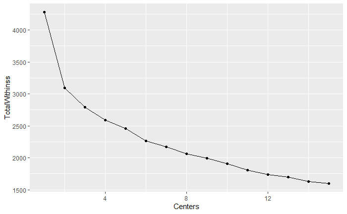

```
[1]  53 162
```

As we don’t see the temporal patterns in the feature-vector representation we join the cluster labels with our normalized price dataset and plot the time series in their respective clusters. We still see the the cycle and trend components in both clusters while also getting the sense of a possible sensible partition between stocks with certain high volatility behavior and stocks that show less movement in their price development.

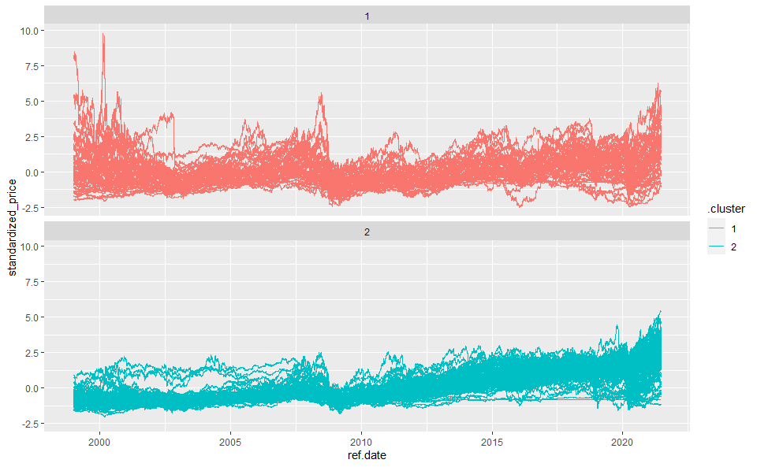

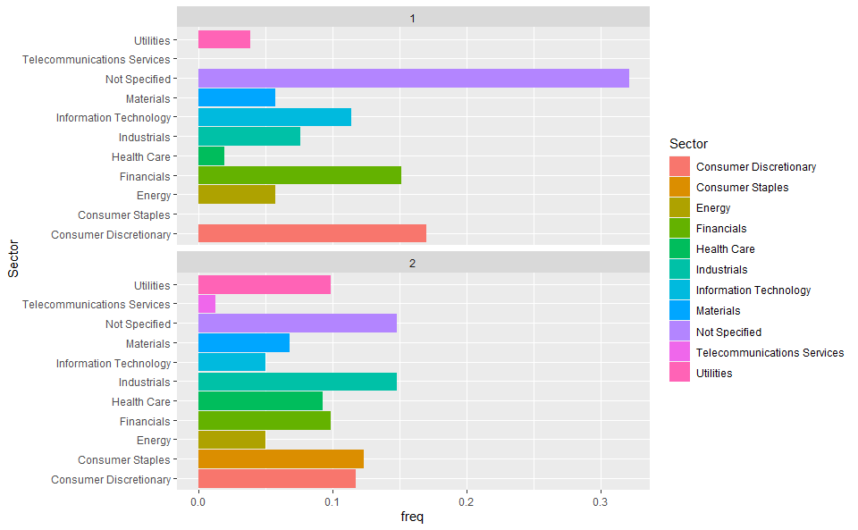

### Further Dimensionality Reduction

In order to even further reduce the dimensions of our already rather slim feature vectors we decided to try a primary component anlysis.

|  | PC01 | PC02 | PC03 | PC04 | PC05 | PC06 | PC07 | PC08 | PC09 | PC10 | PC11 | PC12 | PC13 | PC14 | PC15 | PC16 | PC17 | PC18 | PC19 | PC20 |
| --- | --- | --- | --- | --- | --- | --- | --- | --- | --- | --- | --- | --- | --- | --- | --- | --- | --- | --- | --- | --- |
| AAPL | 1.329543357 | 2.544440842 | -1.2326453534 | -1.196084933 | -0.924408655 | -1.872011e-01 | 0.935894101 | -0.403935002 | 1.119693042 | 0.006504343 | 0.113429253 | -0.1186573621 | -0.706886957 | -0.3458936618 | 0.6039722838 | -0.476993567 | 0.1555812684 | -0.672966187 | -0.382314631 | -0.3336348473 |
| ABT | 2.158001281 | 1.606454577 | -0.2167197073 | -1.071707493 | -0.055943929 | 3.026947e-01 | 1.368397215 | 0.238486839 | 0.246489362 | 0.201010367 | 0.040603501 | -0.4010867972 | -0.669869029 | 0.1254252475 | 0.6368472623 | -0.109765342 | 0.1005552618 | -0.777277562 | -0.075515160 | -0.1338748607 |
| ADM | 1.366159641 | -0.966742275 | -1.4120373274 | 1.847833736 | -0.244495507 | -1.396801e+00 | 0.526951539 | -0.295464675 | 1.787300868 | -1.151055970 | 1.981257357 | 0.3806530206 | 0.101920698 | -0.5552522683 | -0.4508003667 | -0.034070378 | -0.4493458623 | -0.407053105 | -0.123212834 | 0.0992296666 |
| ADP | 1.679814582 | 0.974966407 | 0.4702989534 | -1.568528216 | 0.213186148 | 5.994448e-01 | 0.386745397 | 0.394159566 | -0.553902077 | -0.512281075 | -0.137541680 | -0.5307347368 | -0.192296579 | -0.0739691079 | -0.2529543917 | -0.006080458 | 0.0977126473 | 0.231426610 | 0.224906992 | -0.0305659077 |
| ADSK | 0.272148196 | 1.372364849 | -1.2478148918 | -0.580487496 | -1.572968982 | 1.906081e-01 | -0.859112010 | -0.644319542 | 0.925217231 | -1.008868611 | -0.224897037 | -0.3173659435 | 0.719696414 | 0.1109133785 | 0.2210900611 | -0.501563953 | -0.0758476367 | -0.063171322 | -0.379792215 | -0.0965569576 |
| AEE | 1.143002767 | 0.960079874 | 0.7335033749 | -0.494320779 | 1.067077322 | 1.079836e+00 | -0.446362504 | -0.902257702 | -0.033630300 | 0.179198902 | -1.040937604 | 0.0633109864 | 0.602704362 | 0.1251309794 | 0.4945111841 | 0.214056591 | -0.0615444553 | -0.122075932 | 0.438564146 | 0.0274739635 |
| AEP | 1.803918550 | 0.772353885 | 2.2573470326 | -0.356054100 | 0.912472317 | 3.793576e-01 | -0.978403011 | -1.915406053 | 0.157438366 | 0.080443729 | -0.425646775 | -0.0617995393 | -0.339156491 | 0.0601447742 | -0.2669672321 | 0.325249919 | 0.1943755375 | -0.074038164 | 0.161318540 | 0.2422712844 |
| AIG | 1.361600943 | -0.115453235 | 2.3754914750 | -0.982744560 | -3.191551737 | -3.091358e+00 | 0.245618177 | 0.424177748 | -0.942167305 | 0.489040287 | 2.050594348 | 0.1345080153 | -0.309714628 | 0.4211903952 | -0.3646454400 | -0.256523852 | 0.5430521950 | 0.156716392 | -0.228297904 | -0.0920784188 |
| AIT | 1.935862464 | 0.166393120 | -1.0772416717 | 1.560983252 | -0.113622218 | 1.714739e-01 | 0.010562895 | 0.337666234 | -0.520691193 | 0.968000087 | 0.238797040 | -0.0007337571 | 0.001030977 | -0.9067533776 | -0.3345100271 | -0.311622137 | -0.2009528256 | -0.294771995 | -0.285367682 | -0.1952819423 |
| ALL | 1.175131043 | -0.300831388 | -0.8502821407 | 0.135317331 | -0.943171354 | 8.010847e-02 | -1.277101518 | 0.415499000 | -0.087591428 | 0.197438093 | -0.521939235 | 0.4453342151 | 0.826897729 | 0.0375651134 | -0.3925767332 | -0.071381004 | -0.3348507369 | -0.044043000 | 0.329563155 | 0.1052130266 |

[output cut: 205 more lines]

Looking at the percentages of variation each component explains we can see that the amount of explained variation rapidly decreases. This indicates, that we can most likely only work on a subset of components without loosing a lot of information.

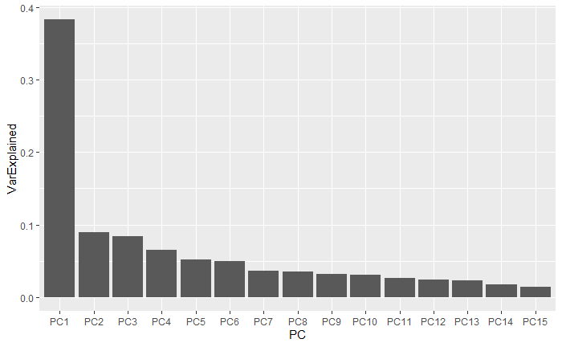

As 15 explain 96.368155% of the variability in our data set we can throw out the last 5 components. With this additional preprocessing step in place we decided to repeat our initial k-means cluster analysis which led to a very similar result. We take this as a further indication that $k=2$ is valid.

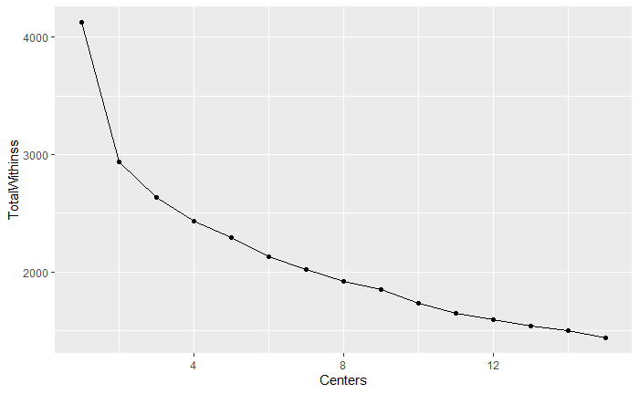

Looking only at the first and the second component we can see that there appears pretty high certainty about the first cluster, which appears to be rather dense while the second cluster has very fuzzy boundaries and less density.

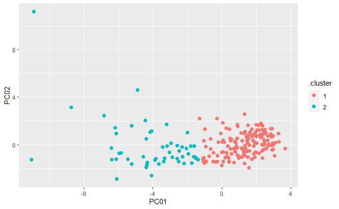

## Clustering via HDBSCAN

```
HDBSCAN clustering for 215 objects.
Parameters: minPts = 4
The clustering contains 4 cluster(s) and 148 noise points.

  0   1   2   3   4
148   4  20   5  38

Available fields: cluster, minPts, cluster_scores, membership_prob, outlier_scores, hc
```

As HDBSCAN is a hierarchical algorithm we can look at its dendrogram. Given that we configured a minimum cluster size of 4 observations the smallest found cluster contains exactly 4 observations.

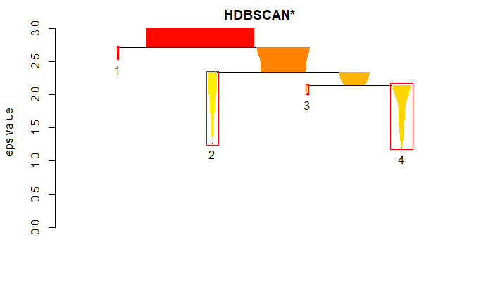

In contrast to the k-means clustering we see that the time series clustered together have to be far more similar to actually land into the same cluster.

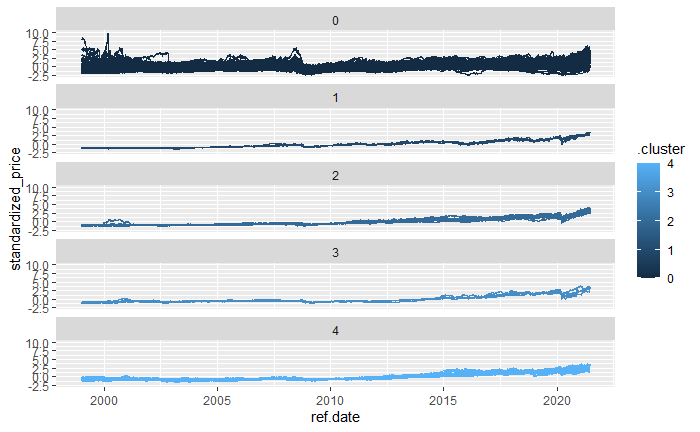

### The Effects of Dimensionality Reduction on HDBSCAN

```
HDBSCAN clustering for 215 objects.
Parameters: minPts = 6
The clustering contains 2 cluster(s) and 163 noise points.

  0   1   2
163  17  35

Available fields: cluster, minPts, cluster_scores, membership_prob, outlier_scores, hc
```

As before we can also inspect the dendrogram, which appears to be flatter and more “balanced” than in our first HDBSCAN experiment.

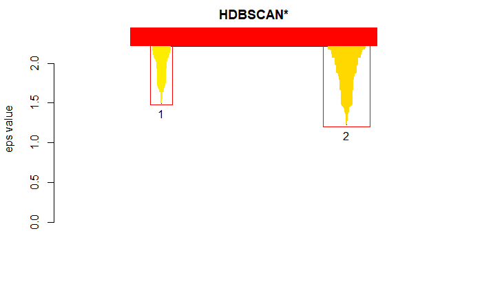

As for the clusters there appears to be an even higher similarity between the time series in each cluster.

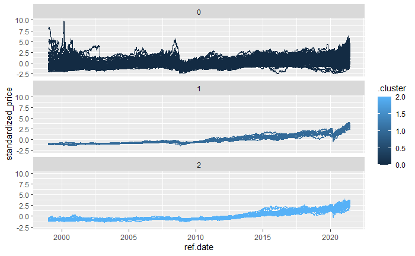

Looking at the relative composition of each cluster we can see a more interesting results than before. The outlier observations as well as the first cluster have around 20% to 25% tickers of not closer specified business sectors in them (the sample has 18.9814815% unspecified values) while the second cluster only has around 5% not closer specified symbols.

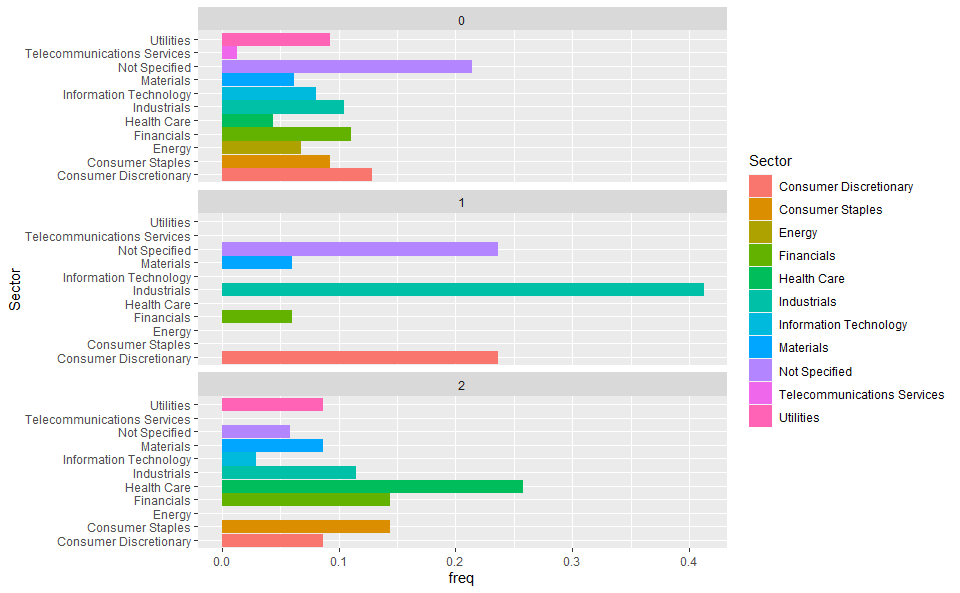

In comparison to the relative composition of the complete sample we can see that the disperse group of outlier observations is relatively similar while the two different clusters are distinctly different.

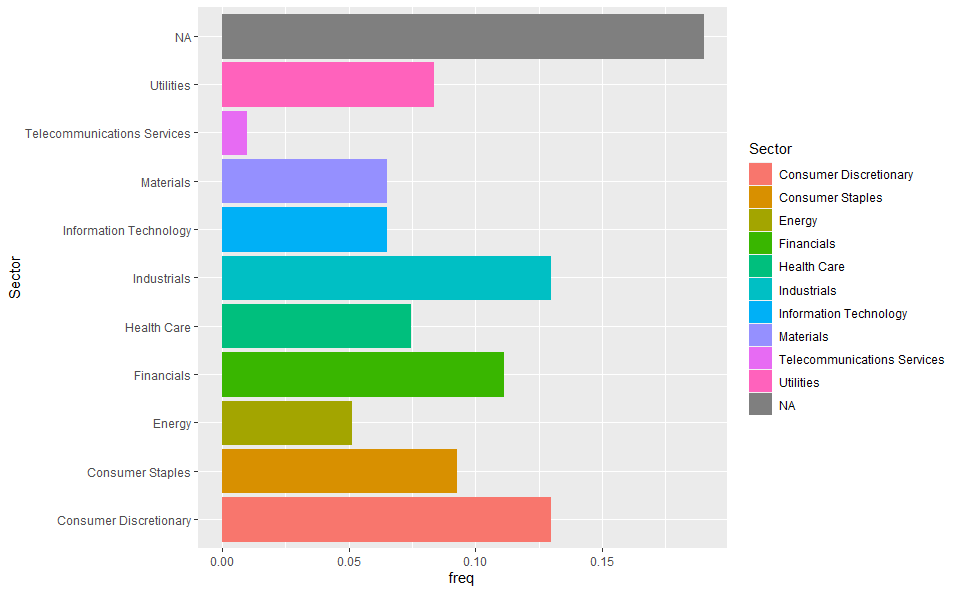

## Exploring Differences in (Financial) Cluster Performance

As we can see above we can already see distinct differences in business sectors which contribute to each cluster. Another interesting piece of additional information for us would be if the clusters we found perform differently from their base index: the S&P 500.

To compare the differences we make use of the `tidyquant` library, a package that includes common functionality used by “quants” (quantitative financial analysts). One of these common functionalities is to calculate the return over a period (in this case monthly) for a set of assets. In the following example we calculate the monthly returns of all tickers in our biggest cluster.

| ticker | date | Ra |
| --- | --- | --- |
| ABT | 1999-01-29 | -0.0443577100 |
| ABT | 1999-02-26 | -0.0026917492 |
| ABT | 1999-03-31 | 0.0107958958 |
| ABT | 1999-04-30 | 0.0367354352 |
| ABT | 1999-05-28 | -0.0658916376 |
| ABT | 1999-06-30 | 0.0041492919 |
| ABT | 1999-07-30 | -0.0498616048 |
| ABT | 1999-08-31 | 0.0101889391 |
| ABT | 1999-09-30 | -0.1541787429 |
| ABT | 1999-10-29 | 0.1051577972 |

[output cut: 990 more lines]

In order to see if our cluster of interest performs better or worse, than the index we have to first retrieve the same returns for the S&P 500. The symbol in question would be `^GSPC`.

| date | Rb |
| --- | --- |
| 1999-01-29 | 4.196730e-02 |
| 1999-02-26 | -3.228256e-02 |
| 1999-03-31 | 3.879422e-02 |
| 1999-04-30 | 3.794403e-02 |
| 1999-05-28 | -2.497048e-02 |
| 1999-06-30 | 5.443833e-02 |
| 1999-07-30 | -3.204609e-02 |
| 1999-08-31 | -6.254092e-03 |
| 1999-09-30 | -2.855179e-02 |
| 1999-10-29 | 6.253954e-02 |

[output cut: 260 more lines]

We can use `tidyquant` to calculate the performance using the monthly returns of our cluster assets as well as the baseline. Unfortunately we would need access to real domain experts for a thorough analysis of the results. As we are not “quants” ourselves we focus on the most intuitive value in the result data set which would be the active premium. The active premium is calculated by subtracting the baseline annualized returns from the asset annualized returns. So - being very reductive - a higher active premium indicates a better performance.

| ticker | ActivePremium | Alpha | AnnualizedAlpha | Beta | Beta- | Beta+ | Correlation | Correlationp-value | InformationRatio | R-squared | TrackingError | TreynorRatio |
| --- | --- | --- | --- | --- | --- | --- | --- | --- | --- | --- | --- | --- |
| ABT | 0.0463 | 0.0072 | 0.0896 | 0.4832 | 0.3214 | 0.4933 | 0.3634 | 0.0000 | 0.2299 | 0.1320 | 0.2014 | 0.2073 |
| ADP | 0.0498 | 0.0057 | 0.0709 | 0.8163 | 0.7807 | 0.8765 | 0.5884 | 0.0000 | 0.2924 | 0.3462 | 0.1703 | 0.1304 |
| ALL | 0.0263 | 0.0047 | 0.0574 | 0.9339 | 1.1456 | 0.9866 | 0.5223 | 0.0000 | 0.1146 | 0.2728 | 0.2292 | 0.0846 |
| APD | 0.0681 | 0.0070 | 0.0867 | 0.9540 | 0.7755 | 0.9746 | 0.5901 | 0.0000 | 0.3482 | 0.3482 | 0.1957 | 0.1300 |
| BDX | 0.0402 | 0.0069 | 0.0855 | 0.5214 | 0.8366 | 0.0117 | 0.3543 | 0.0000 | 0.1843 | 0.1255 | 0.2183 | 0.1843 |
| CAG | -0.0024 | 0.0039 | 0.0477 | 0.5546 | 0.7067 | 0.6119 | 0.3404 | 0.0000 | -0.0099 | 0.1159 | 0.2392 | 0.0932 |
| CCI | 0.0593 | 0.0099 | 0.1253 | 1.3045 | 0.9235 | 1.3978 | 0.4474 | 0.0000 | 0.1507 | 0.2002 | 0.3933 | 0.0900 |
| CI | 0.0573 | 0.0090 | 0.1132 | 0.9054 | 1.5797 | 0.5758 | 0.4121 | 0.0000 | 0.1903 | 0.1698 | 0.3009 | 0.1204 |
| CLX | 0.0224 | 0.0063 | 0.0784 | 0.3184 | 0.2848 | 0.1196 | 0.2359 | 0.0001 | 0.1011 | 0.0557 | 0.2214 | 0.2455 |
| CVS | 0.0121 | 0.0043 | 0.0530 | 0.7367 | 0.5955 | 0.6339 | 0.4251 | 0.0000 | 0.0506 | 0.1807 | 0.2384 | 0.0910 |

[output cut: 25 more lines]

If we look at the active premium distribution for our cluster assets we can see that the median active premium is 4.79% while the whole distribution generally stayes to the right of the parity line.

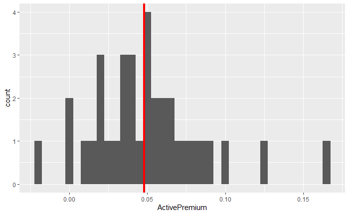

## Analysis of Temporal Cluster Stability

Another question we had was whether symbols that get clustered together when looking at the complete time frame of available data, show changing cluster membership when looking at them in sliding windows. We decided to look at sliding windows of three years as those are wide enough to span complete recession events (at least in many cases).

We began with looking at the first window from 1999 to 2002 to see if we could find a pattern similar to the ones we observed when looking at the complete time frame. The data - of course - looks exactly as we saw it before, just focuseed on the first three years.

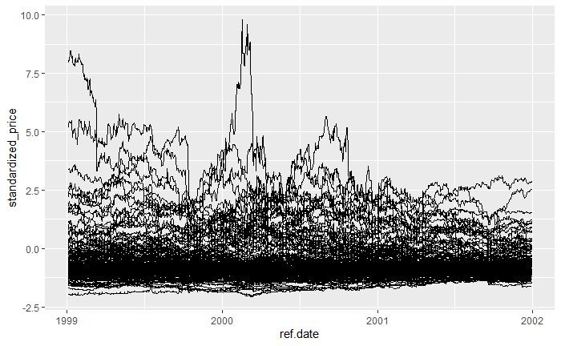

Unfortunately we already see, that if we stick with the default minimal number of points in a cluster we only see ‘noise’. There are no clusters to see.

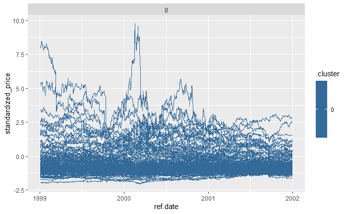

Of course, we can increase the window length and decrease the minimum amount of points per cluster and see if we can get some sort of stability this way.

| ticker | 1999_2006 | 2000_2007 | 2001_2008 | 2002_2009 | 2003_2010 | 2004_2011 | 2005_2012 | 2006_2013 | 2007_2014 | 2008_2015 | 2009_2016 | 2010_2017 | 2011_2018 | 2012_2019 | 2013_2020 | 2014_2021 |
| --- | --- | --- | --- | --- | --- | --- | --- | --- | --- | --- | --- | --- | --- | --- | --- | --- |
| AAPL | 0 | 2 | 2 | 2 | 0 | 0 | 2 | 2 | 2 | 0 | 2 | 3 | 3 | 0 | 2 | 2 |
| ABT | 0 | 0 | 2 | 2 | 0 | 0 | 0 | 2 | 2 | 0 | 2 | 3 | 0 | 0 | 2 | 2 |
| ADM | 0 | 2 | 2 | 2 | 4 | 3 | 0 | 0 | 2 | 0 | 2 | 2 | 0 | 0 | 0 | 2 |
| ADP | 0 | 0 | 0 | 0 | 0 | 0 | 2 | 2 | 2 | 0 | 2 | 3 | 3 | 2 | 2 | 2 |
| ADSK | 0 | 0 | 2 | 2 | 0 | 0 | 0 | 0 | 2 | 0 | 2 | 0 | 0 | 0 | 2 | 2 |
| AEE | 0 | 2 | 2 | 2 | 3 | 0 | 0 | 2 | 0 | 0 | 2 | 3 | 3 | 2 | 2 | 2 |
| AEP | 0 | 0 | 2 | 2 | 4 | 3 | 1 | 2 | 2 | 3 | 2 | 3 | 0 | 0 | 2 | 2 |
| AIG | 0 | 0 | 0 | 0 | 0 | 0 | 0 | 0 | 0 | 0 | 2 | 2 | 1 | 0 | 1 | 0 |
| AIT | 0 | 2 | 2 | 2 | 4 | 0 | 0 | 2 | 2 | 0 | 2 | 3 | 2 | 0 | 0 | 2 |
| ALL | 0 | 2 | 2 | 0 | 0 | 0 | 0 | 2 | 0 | 0 | 2 | 3 | 1 | 1 | 2 | 2 |

[output cut: 205 more lines]

We can count how often our time series “change membership” and how often each label is applied to them. As the cluster label isn’t learned in the sense of a supervised or semi-supervised algorithm these labels don’t mean a lot (neither do they guarantee that the same label means the same thing in the same context). In the context of this hierarchical clustering we just assume, that a label moniker means the same thing over time.

| ticker | memberships | outlier_count | first_count | second_count | third_count | fourth_cluster |
| --- | --- | --- | --- | --- | --- | --- |
| ECL | 4 | 2 | 2 | 10 | 0 | 2 |
| TJX | 4 | 2 | 4 | 8 | 0 | 0 |
| LMT | 4 | 3 | 0 | 9 | 2 | 2 |
| MCO | 4 | 3 | 2 | 9 | 2 | 0 |
| NSC | 4 | 3 | 0 | 8 | 4 | 1 |
| AEP | 5 | 4 | 1 | 7 | 3 | 1 |
| CLX | 4 | 4 | 1 | 8 | 3 | 0 |
| COST | 4 | 4 | 2 | 8 | 2 | 0 |
| DTE | 3 | 4 | 0 | 10 | 2 | 0 |
| INGR | 3 | 4 | 0 | 9 | 3 | 0 |

[output cut: 203 more lines]

As we’d still like to compare the different clusters (even in this windowed form) we have to summarize the results in some at least partially meaningful way. We chose to take the mode of the cluster label or each stock as a method to say “this stock belongs to this cluster”. As we’ve already discussed most of them would be “noise”.

| ticker | mode_cluster |
| --- | --- |
| AAPL | 2 |
| ABT | 0 |
| ADM | 0 |
| ADP | 0 |
| ADSK | 0 |
| AEE | 2 |
| AEP | 2 |
| AIG | 0 |
| AIT | 2 |
| ALL | 0 |

[output cut: 205 more lines]

If we look at the different performance of each cluster we see a picture, that could be interpreted as pointing in the direction, that there are some clusters which have some temporal stability and perform better than the base line index.

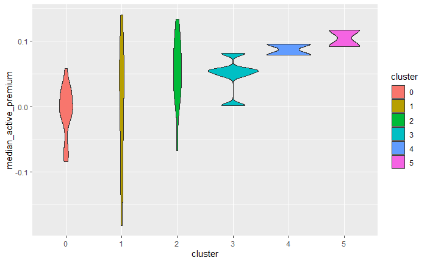

Looking at the sizes of each clusters and the flaky (at best) methods we used to get to these outcomes we’d conclude that it does not appear to be possible to use these time series characteristics to find the best all-time-well-performing stocks in comparison to a base index. Of course, there are other methods to find more subtle similarities between time series. Dynamic time warping would offer a distance metric which does not need to reduce the temporal information in the same way as computing time series features would. In any case further investigation would be needed.